# **Marketplace Analytics: FoodHub Courier Demand and Sales Optimization**

# Continued Multivariate Analysis

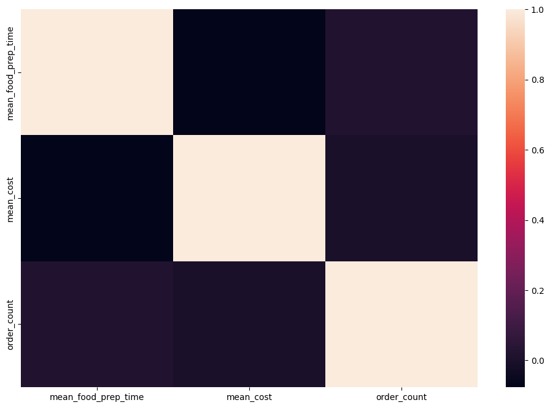

```python
# Visualizing the correlation between restaurant popularity, cost and prep time.
numeric_summary = summary[["mean_food_prep_time", "mean_cost", "order_count"]]
summary_corr = numeric_summary.corr()

plt.figure(figsize=(12,8))
sns.heatmap(summary_corr)
```

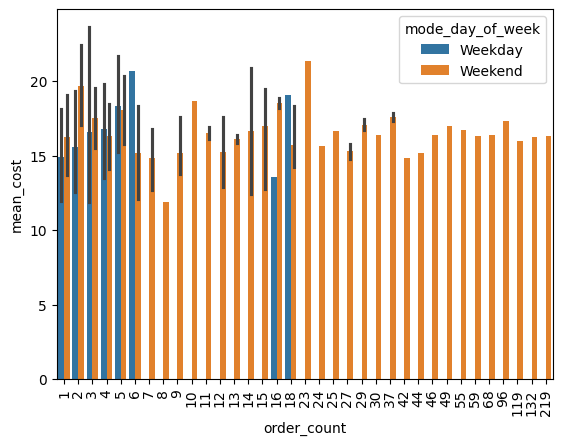

```python
sns.barplot(data=summary, x="order_count", y="mean_cost", hue="mode_day_of_week")
plt.xticks(rotation=90);
```

### Observations:

Restaurants showing a weekday consumer preference are largely concentrated amongst the lowest volume resaurants, never surpassing an order count greater than 18.

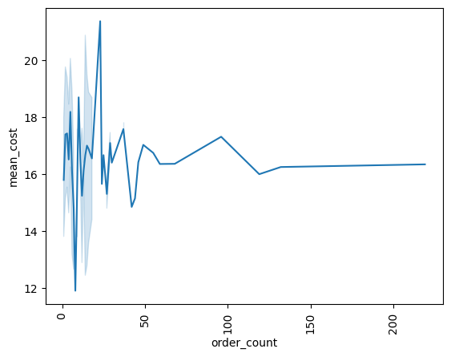

```python
# Visualizing the average cost of an order by restaurant volume
sns.lineplot(data=summary, x="order_count", y="mean_cost")
plt.xticks(rotation=90);
```

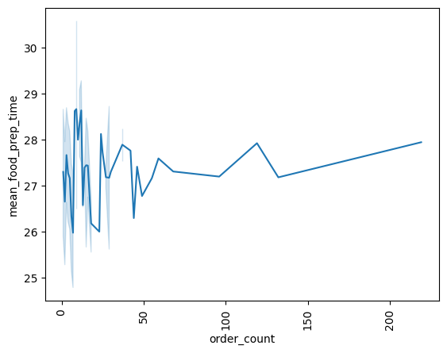

```python
# Visualizing the average amount of prep time by restaurant volume
sns.lineplot(data=summary, x="order_count", y="mean_food_prep_time")
plt.xticks(rotation=90);
```

### Observations:

#### However, restaurants with higher order volumes tend to have more consistent average prices and total wait times.

#### Higher volume ranges: 16-17 dollars, 27-28 minutes

#### Lower volume ranges: 12-23 dollars, 24-31 minutes

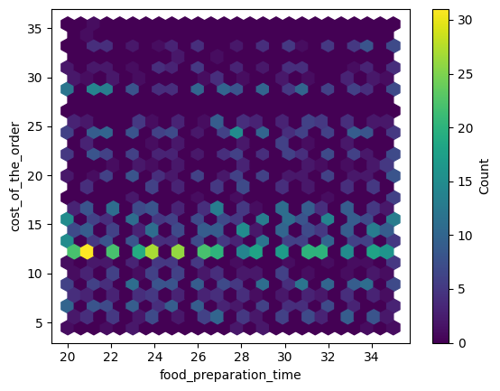

```python
# Checking once more for underlaying/overlooked correlations
plt.hexbin(df['food_preparation_time'], df['cost_of_the_order'], gridsize=25)
plt.colorbar(label='Count')
plt.xlabel('food_preparation_time')
plt.ylabel('cost_of_the_order')
```

### Observations:

#### Again the $13 dollar peak is showing as in prior visualizations, with a wider range of prep times between 20 and 35 minutes and higher concentration in the lower range (20-24). There aren't significant differences in costs between weekend and weekday orders.

# Repeat Customer Analysis

As previously shown, there are a smaller amount of individual patron account numbers (Order ID) than there are entries in the data, indicating that there are repeat customers. The following section explores consumer behavior as expressed through loyalty and how it pertains to different volume tiers of business.

```python
# Rechecking the average timing, cost, and total orders of restaurants by volume.
restaurant_volume_query = """
SELECT
    restaurant_name,
    COUNT(*) AS total_orders,
    ROUND(AVG(cost_of_the_order), 2) AS avg_order_value,
    ROUND(AVG(food_preparation_time + delivery_time), 2) AS avg_total_fulfillment_time
FROM orders
GROUP BY restaurant_name
ORDER BY total_orders DESC;
"""

pd.read_sql(restaurant_volume_query, conn)
```

|  | restaurant_name | total_orders | avg_order_value | avg_total_fulfillment_time |
| --- | --- | --- | --- | --- |
| 0 | Shake Shack | 219 | 16.34 | 52.61 |
| 1 | The Meatball Shop | 132 | 16.25 | 51.42 |
| 2 | Blue Ribbon Sushi | 119 | 16.00 | 51.87 |
| 3 | Blue Ribbon Fried Chicken | 96 | 17.32 | 51.34 |
| 4 | Parm | 68 | 16.36 | 52.81 |
| ... | ... | ... | ... | ... |
| 173 | Balade | 1 | 9.22 | 49.00 |
| 174 | Anjappar Chettinad | 1 | 16.44 | 47.00 |
| 175 | Alidoro | 1 | 12.61 | 56.00 |
| 176 | 67 Burger | 1 | 29.05 | 48.00 |
| 177 | 'wichcraft | 1 | 8.10 | 56.00 |

178 rows × 4 columns

```python
# Labelling restaruants with size-band tiers
restaurant_size_band_query = """
WITH restaurant_orders AS (
    SELECT
        restaurant_name,
        COUNT(*) AS total_orders
    FROM orders
    GROUP BY restaurant_name
)
SELECT
    restaurant_name,
    total_orders,
    CASE
        WHEN total_orders < 10 THEN 'Low-volume'
        WHEN total_orders BETWEEN 10 AND 29 THEN 'Mid-size'
        ELSE 'High-volume'
    END AS restaurant_size_band
FROM restaurant_orders
ORDER BY total_orders DESC;
"""

pd.read_sql(restaurant_size_band_query, conn)
```

|  | restaurant_name | total_orders | restaurant_size_band |
| --- | --- | --- | --- |
| 0 | Shake Shack | 219 | High-volume |
| 1 | The Meatball Shop | 132 | High-volume |
| 2 | Blue Ribbon Sushi | 119 | High-volume |
| 3 | Blue Ribbon Fried Chicken | 96 | High-volume |
| 4 | Parm | 68 | High-volume |
| ... | ... | ... | ... |
| 173 | Taro Sushi | 1 | Low-volume |
| 174 | The MasalaWala | 1 | Low-volume |
| 175 | Wa Jeal | 1 | Low-volume |
| 176 | Wo Hop Restaurant | 1 | Low-volume |
| 177 | Woorijip | 1 | Low-volume |

178 rows × 3 columns

```python
# Checking top repeat patrons amidst dataset
customer_restaurant_repeat_query = """
SELECT
    restaurant_name,
    customer_id,
    COUNT(*) AS visits_to_same_restaurant
FROM orders
GROUP BY restaurant_name, customer_id
HAVING COUNT(*) >= 1
ORDER BY visits_to_same_restaurant DESC, restaurant_name;
"""

pd.read_sql(customer_restaurant_repeat_query, conn)
```

|  | restaurant_name | customer_id | visits_to_same_restaurant |
| --- | --- | --- | --- |
| 0 | Bareburger | 47440 | 6 |
| 1 | Blue Ribbon Sushi Bar & Grill | 97991 | 6 |
| 2 | Shake Shack | 97806 | 5 |
| 3 | The Meatball Shop | 84087 | 5 |
| 4 | Benihana | 97079 | 4 |
| ... | ... | ... | ... |
| 1430 | ilili Restaurant | 201471 | 1 |
| 1431 | ilili Restaurant | 301380 | 1 |
| 1432 | ilili Restaurant | 362961 | 1 |
| 1433 | indikitch | 7567 | 1 |
| 1434 | indikitch | 373353 | 1 |

1435 rows × 3 columns

```python
# Checking customer retention rate of restaurants, geenrating repeat customer rate
restaurant_retention_query = """
WITH customer_visits AS (
    SELECT
        restaurant_name,
        customer_id,
        COUNT(*) AS visits
    FROM orders
    GROUP BY restaurant_name, customer_id
),
restaurant_retention AS (
    SELECT
        restaurant_name,
        COUNT(*) AS unique_customers,
        SUM(CASE WHEN visits = 1 THEN 1 ELSE 0 END) AS one_time_customers,
        SUM(CASE WHEN visits >= 2 THEN 1 ELSE 0 END) AS repeat_customers
    FROM customer_visits
    GROUP BY restaurant_name
)
SELECT
    restaurant_name,
    unique_customers,
    one_time_customers,
    repeat_customers,
    ROUND(100.0 * repeat_customers / unique_customers, 2) AS repeat_customer_rate
FROM restaurant_retention
WHERE unique_customers >= 5
ORDER BY repeat_customer_rate DESC, unique_customers DESC;
"""

pd.read_sql(restaurant_retention_query, conn)
```

|  | restaurant_name | unique_customers | one_time_customers | repeat_customers | repeat_customer_rate |
| --- | --- | --- | --- | --- | --- |
| 0 | Blue Ribbon Sushi Bar & Grill | 25 | 13 | 12 | 48.00 |
| 1 | The Smile | 11 | 6 | 5 | 45.45 |
| 2 | Vanessa's Dumplings | 9 | 5 | 4 | 44.44 |
| 3 | ilili Restaurant | 12 | 7 | 5 | 41.67 |
| 4 | Blue Ribbon Sushi | 75 | 44 | 31 | 41.33 |
| 5 | Sushi of Gari Tribeca | 15 | 9 | 6 | 40.00 |
| 6 | Osteria Morini | 10 | 6 | 4 | 40.00 |
| 7 | P.J. Clarke's | 10 | 6 | 4 | 40.00 |
| 8 | Sarabeth's Restaurant | 5 | 3 | 2 | 40.00 |
| 9 | Vanessa's Dumpling House | 5 | 3 | 2 | 40.00 |
| 10 | Melt Shop | 8 | 5 | 3 | 37.50 |
| 11 | Sushi Samba | 8 | 5 | 3 | 37.50 |
| 12 | Sushi of Gari | 11 | 7 | 4 | 36.36 |
| 13 | Westville Hudson | 11 | 7 | 4 | 36.36 |
| 14 | Momoya | 21 | 14 | 7 | 33.33 |
| 15 | Otto Enoteca Pizzeria | 9 | 6 | 3 | 33.33 |
| 16 | Boqueria | 6 | 4 | 2 | 33.33 |
| 17 | Cafeteria | 6 | 4 | 2 | 33.33 |
| 18 | Xi'an Famous Foods | 6 | 4 | 2 | 33.33 |
| 19 | Yama Japanese Restaurant | 13 | 9 | 4 | 30.77 |
| 20 | RedFarm Broadway | 43 | 30 | 13 | 30.23 |
| 21 | Hill Country Fried Chicken | 10 | 7 | 3 | 30.00 |
| 22 | Blue Ribbon Fried Chicken | 68 | 48 | 20 | 29.41 |
| 23 | Balthazar Boulangerie | 7 | 5 | 2 | 28.57 |
| 24 | Bareburger | 18 | 13 | 5 | 27.78 |
| 25 | TAO | 37 | 27 | 10 | 27.03 |
| 26 | Nobu Next Door | 30 | 22 | 8 | 26.67 |
| 27 | Jack's Wife Freda | 19 | 14 | 5 | 26.32 |
| 28 | Sushi of Gari 46 | 28 | 21 | 7 | 25.00 |
| 29 | J. G. Melon | 12 | 9 | 3 | 25.00 |
| 30 | Tamarind TriBeCa | 21 | 16 | 5 | 23.81 |
| 31 | The Meatball Shop | 102 | 78 | 24 | 23.53 |
| 32 | Shake Shack | 170 | 133 | 37 | 21.76 |
| 33 | Parm | 56 | 44 | 12 | 21.43 |
| 34 | Chipotle Mexican Grill $1.99 Delivery | 19 | 15 | 4 | 21.05 |
| 35 | Cafe Mogador | 15 | 12 | 3 | 20.00 |
| 36 | Empanada Mama (closed) | 10 | 8 | 2 | 20.00 |
| 37 | CafÌ© China | 5 | 4 | 1 | 20.00 |
| 38 | Hatsuhana | 5 | 4 | 1 | 20.00 |
| 39 | L'Express | 5 | 4 | 1 | 20.00 |
| 40 | Han Dynasty | 36 | 29 | 7 | 19.44 |
| 41 | RedFarm Hudson | 44 | 36 | 8 | 18.18 |
| 42 | Blue Ribbon Sushi Izakaya | 22 | 18 | 4 | 18.18 |
| 43 | Mamoun's Falafel | 6 | 5 | 1 | 16.67 |
| 44 | Pepe Rosso To Go | 6 | 5 | 1 | 16.67 |
| 45 | Sarabeth's East | 6 | 5 | 1 | 16.67 |
| 46 | Five Guys Burgers and Fries | 25 | 21 | 4 | 16.00 |
| 47 | Rubirosa | 32 | 27 | 5 | 15.63 |
| 48 | Cafe Habana | 13 | 11 | 2 | 15.38 |
| 49 | The Kati Roll Company | 14 | 12 | 2 | 14.29 |
| 50 | Dos Caminos | 7 | 6 | 1 | 14.29 |
| 51 | Burger Joint | 12 | 12 | 0 | 0.00 |
| 52 | S'MAC | 12 | 12 | 0 | 0.00 |
| 53 | Barbounia | 6 | 6 | 0 | 0.00 |
| 54 | Saravanaa Bhavan | 5 | 5 | 0 | 0.00 |
| 55 | Serafina Fabulous Pizza | 5 | 5 | 0 | 0.00 |
| 56 | Yama 49 | 5 | 5 | 0 | 0.00 |

```python
# Calculating retention averages per size band
retention_by_size_band_query = """
WITH restaurant_orders AS (
    SELECT
        restaurant_name,
        COUNT(*) AS total_orders
    FROM orders
    GROUP BY restaurant_name
),
restaurant_bands AS (
    SELECT
        restaurant_name,
        total_orders,
        CASE
            WHEN total_orders < 10 THEN 'Low-volume'
            WHEN total_orders BETWEEN 10 AND 29 THEN 'Mid-size'
            ELSE 'High-volume'
        END AS restaurant_size_band
    FROM restaurant_orders
),
customer_visits AS (
    SELECT
        restaurant_name,
        customer_id,
        COUNT(*) AS visits
    FROM orders
    GROUP BY restaurant_name, customer_id
),
restaurant_retention AS (
    SELECT
        restaurant_name,
        COUNT(*) AS unique_customers,
        SUM(CASE WHEN visits = 1 THEN 1 ELSE 0 END) AS one_time_customers,
        SUM(CASE WHEN visits >= 2 THEN 1 ELSE 0 END) AS repeat_customers
    FROM customer_visits
    GROUP BY restaurant_name
)
SELECT
    rb.restaurant_size_band,
    COUNT(*) AS num_restaurants,
    ROUND(AVG(rr.unique_customers), 2) AS avg_unique_customers,
    ROUND(AVG(rr.repeat_customers), 2) AS avg_repeat_customers,
    ROUND(AVG(100.0 * rr.repeat_customers / rr.unique_customers), 2) AS avg_repeat_customer_rate
FROM restaurant_bands rb
JOIN restaurant_retention rr
    ON rb.restaurant_name = rr.restaurant_name
WHERE rr.unique_customers >= 5
GROUP BY rb.restaurant_size_band
ORDER BY
    CASE rb.restaurant_size_band
        WHEN 'Low-volume' THEN 1
        WHEN 'Mid-size' THEN 2
        ELSE 3
    END;
"""

pd.read_sql(retention_by_size_band_query, conn)
```

|  | restaurant_size_band | num_restaurants | avg_unique_customers | avg_repeat_customers | avg_repeat_customer_rate |
| --- | --- | --- | --- | --- | --- |
| 0 | Low-volume | 16 | 5.56 | 1.06 | 19.02 |
| 1 | Mid-size | 27 | 13.19 | 3.44 | 27.77 |
| 2 | High-volume | 14 | 54.79 | 14.36 | 27.21 |

```python
# Gathering counts on repeat customers by frequency
deep_repeaters_by_restaurant_query = """
WITH customer_visits AS (
    SELECT
        restaurant_name,
        customer_id,
        COUNT(*) AS visits
    FROM orders
    GROUP BY restaurant_name, customer_id
)
SELECT
    restaurant_name,
    COUNT(*) AS customer_pairs,
    SUM(CASE WHEN visits = 1 THEN 1 ELSE 0 END) AS one_visit_customers,
    SUM(CASE WHEN visits = 2 THEN 1 ELSE 0 END) AS two_visit_customers,
    SUM(CASE WHEN visits = 3 THEN 1 ELSE 0 END) AS three_visit_customers,
    SUM(CASE WHEN visits >= 4 THEN 1 ELSE 0 END) AS four_plus_visit_customers
FROM customer_visits
GROUP BY restaurant_name
HAVING COUNT(*) >= 5
ORDER BY three_visit_customers DESC, four_plus_visit_customers DESC;
"""

pd.read_sql(deep_repeaters_by_restaurant_query, conn)
```

|  | restaurant_name | customer_pairs | one_visit_customers | two_visit_customers | three_visit_customers | four_plus_visit_customers |
| --- | --- | --- | --- | --- | --- | --- |
| 0 | Shake Shack | 170 | 133 | 28 | 7 | 2 |
| 1 | Blue Ribbon Fried Chicken | 68 | 48 | 14 | 4 | 2 |
| 2 | Blue Ribbon Sushi Bar & Grill | 25 | 13 | 8 | 3 | 1 |
| 3 | The Meatball Shop | 102 | 78 | 20 | 3 | 1 |
| 4 | RedFarm Hudson | 44 | 36 | 5 | 3 | 0 |
| 5 | Nobu Next Door | 30 | 22 | 5 | 2 | 1 |
| 6 | Sushi of Gari 46 | 28 | 21 | 5 | 2 | 0 |
| 7 | TAO | 37 | 27 | 8 | 2 | 0 |
| 8 | Vanessa's Dumpling House | 5 | 3 | 0 | 2 | 0 |
| 9 | Blue Ribbon Sushi | 75 | 44 | 24 | 1 | 6 |
| 10 | Blue Ribbon Sushi Izakaya | 22 | 18 | 2 | 1 | 1 |
| 11 | Han Dynasty | 36 | 29 | 5 | 1 | 1 |
| 12 | RedFarm Broadway | 43 | 30 | 11 | 1 | 1 |
| 13 | Sushi of Gari Tribeca | 15 | 9 | 4 | 1 | 1 |
| 14 | Balthazar Boulangerie | 7 | 5 | 1 | 1 | 0 |
| 15 | Boqueria | 6 | 4 | 1 | 1 | 0 |
| 16 | Cafe Habana | 13 | 11 | 1 | 1 | 0 |
| 17 | Cafeteria | 6 | 4 | 1 | 1 | 0 |
| 18 | Empanada Mama (closed) | 10 | 8 | 1 | 1 | 0 |
| 19 | Hill Country Fried Chicken | 10 | 7 | 2 | 1 | 0 |
| 20 | Jack's Wife Freda | 19 | 14 | 4 | 1 | 0 |
| 21 | P.J. Clarke's | 10 | 6 | 3 | 1 | 0 |
| 22 | Sushi of Gari | 11 | 7 | 3 | 1 | 0 |
| 23 | Tamarind TriBeCa | 21 | 16 | 4 | 1 | 0 |
| 24 | Xi'an Famous Foods | 6 | 4 | 1 | 1 | 0 |
| 25 | Yama Japanese Restaurant | 13 | 9 | 3 | 1 | 0 |
| 26 | ilili Restaurant | 12 | 7 | 4 | 1 | 0 |
| 27 | Bareburger | 18 | 13 | 4 | 0 | 1 |
| 28 | Momoya | 21 | 14 | 6 | 0 | 1 |
| 29 | The Smile | 11 | 6 | 4 | 0 | 1 |
| 30 | Barbounia | 6 | 6 | 0 | 0 | 0 |
| 31 | Burger Joint | 12 | 12 | 0 | 0 | 0 |
| 32 | Cafe Mogador | 15 | 12 | 3 | 0 | 0 |
| 33 | CafÌ© China | 5 | 4 | 1 | 0 | 0 |
| 34 | Chipotle Mexican Grill $1.99 Delivery | 19 | 15 | 4 | 0 | 0 |
| 35 | Dos Caminos | 7 | 6 | 1 | 0 | 0 |
| 36 | Five Guys Burgers and Fries | 25 | 21 | 4 | 0 | 0 |
| 37 | Hatsuhana | 5 | 4 | 1 | 0 | 0 |
| 38 | J. G. Melon | 12 | 9 | 3 | 0 | 0 |
| 39 | L'Express | 5 | 4 | 1 | 0 | 0 |
| 40 | Mamoun's Falafel | 6 | 5 | 1 | 0 | 0 |
| 41 | Melt Shop | 8 | 5 | 3 | 0 | 0 |
| 42 | Osteria Morini | 10 | 6 | 4 | 0 | 0 |
| 43 | Otto Enoteca Pizzeria | 9 | 6 | 3 | 0 | 0 |
| 44 | Parm | 56 | 44 | 12 | 0 | 0 |
| 45 | Pepe Rosso To Go | 6 | 5 | 1 | 0 | 0 |
| 46 | Rubirosa | 32 | 27 | 5 | 0 | 0 |
| 47 | S'MAC | 12 | 12 | 0 | 0 | 0 |
| 48 | Sarabeth's East | 6 | 5 | 1 | 0 | 0 |
| 49 | Sarabeth's Restaurant | 5 | 3 | 2 | 0 | 0 |
| 50 | Saravanaa Bhavan | 5 | 5 | 0 | 0 | 0 |
| 51 | Serafina Fabulous Pizza | 5 | 5 | 0 | 0 | 0 |
| 52 | Sushi Samba | 8 | 5 | 3 | 0 | 0 |
| 53 | The Kati Roll Company | 14 | 12 | 2 | 0 | 0 |
| 54 | Vanessa's Dumplings | 9 | 5 | 4 | 0 | 0 |
| 55 | Westville Hudson | 11 | 7 | 4 | 0 | 0 |
| 56 | Yama 49 | 5 | 5 | 0 | 0 | 0 |

```python
# Computing ratio of repeat customers to one time customers amongst data
platform_repeat_mix_query = """
WITH customer_visits AS (
    SELECT
        restaurant_name,
        customer_id,
        COUNT(*) AS visits
    FROM orders
    GROUP BY restaurant_name, customer_id
)
SELECT
    SUM(CASE WHEN visits = 1 THEN 1 ELSE 0 END) AS one_time_customer_restaurant_pairs,
    SUM(CASE WHEN visits >= 2 THEN 1 ELSE 0 END) AS repeat_customer_restaurant_pairs,
    ROUND(
        100.0 * SUM(CASE WHEN visits >= 2 THEN 1 ELSE 0 END) / COUNT(*),
        2
    ) AS pct_repeat_customer_restaurant_pairs
FROM customer_visits;
"""

pd.read_sql(platform_repeat_mix_query, conn)
```

|  | one_time_customer_restaurant_pairs | repeat_customer_restaurant_pairs | pct_repeat_customer_restaurant_pairs |
| --- | --- | --- | --- |
| 0 | 1076 | 359 | 25.02 |

### Key Takeaways:

Order volume is concentrated among high-volume restaurants, which has also showed more consistent pricing and fulfillment times. Segmenting by size reveals clear structural differences across the platform.

Repeat behavior is not limited to large restaurants. Mid-size establishments show comparable repeat customer rates, indicating a stronger balance between acquisition and retention, while low-volume restaurants see minimal repeat activity.

At the platform level, repeat engagement is present but limited, with roughly a quarter of customer–restaurant interactions being repeat visits. Most of this activity comes from low-frequency returns rather than strong customer loyalty.

While SQL is used to construct these aggregated datasets efficiently and transparently at the database level, the results are subsequently brought into Python to leverage its more flexible visualization capabilities for clearer comparison and presentation.

```python
# Creating a table that groups dataset by customer and restaurant
fun = (
    df.groupby(['restaurant_name', 'cuisine_type'])['customer_id']
      .value_counts()                     # how many orders per customer at that restaurant
      .rename('count')                    # give the Series a name
      .reset_index()                      # convert MultiIndex → columns
)
fun
```

|  | restaurant_name | cuisine_type | customer_id | count |
| --- | --- | --- | --- | --- |
| 0 | 'wichcraft | American | 321492 | 1 |
| 1 | 12 Chairs | Middle Eastern | 115610 | 1 |
| 2 | 12 Chairs | Middle Eastern | 225912 | 1 |
| 3 | 12 Chairs | Middle Eastern | 276192 | 1 |
| 4 | 12 Chairs | Middle Eastern | 375098 | 1 |
| ... | ... | ... | ... | ... |
| 1431 | ilili Restaurant | Middle Eastern | 301380 | 1 |
| 1432 | ilili Restaurant | Middle Eastern | 362961 | 1 |
| 1433 | indikitch | Indian | 353676 | 2 |
| 1434 | indikitch | Indian | 7567 | 1 |
| 1435 | indikitch | Indian | 373353 | 1 |

1436 rows × 4 columns

```python
# Regenerating columns that contain counts of each repeat customer by frequency
fun_pivot = (
    fun
    .groupby(['restaurant_name', 'cuisine_type'])['count']
    .value_counts()            # how many customers with each visit-count
    .unstack(fill_value=0)     # columns 1,2,3,4,5,6
)

# Ensuring columns are 1–6 in order, filling missing with 0
fun_pivot = fun_pivot.reindex(columns=[1, 2, 3, 4, 5, 6], fill_value=0)

# Changing column names to be more legible
fun_pivot.columns = [f'count_{c}' for c in fun_pivot.columns]

# Bring index back as columns if you like
fun_pivot = fun_pivot.reset_index()

fun_pivot.head()
```

|  | restaurant_name | cuisine_type | count_1 | count_2 | count_3 | count_4 | count_5 | count_6 |
| --- | --- | --- | --- | --- | --- | --- | --- | --- |
| 0 | 'wichcraft | American | 1 | 0 | 0 | 0 | 0 | 0 |
| 1 | 12 Chairs | Middle Eastern | 4 | 0 | 0 | 0 | 0 | 0 |
| 2 | 5 Napkin Burger | American | 3 | 1 | 0 | 0 | 0 | 0 |
| 3 | 67 Burger | American | 1 | 0 | 0 | 0 | 0 | 0 |
| 4 | Alidoro | American | 1 | 0 | 0 | 0 | 0 | 0 |

#### Note:

#### The above table shows the amount of repeat customers per restaurant, organized by frequency level. For example, a restaurant with an entry of 3 in count_4 means it had 3 customers that placed 4 orders each.

```python
# Adding a column containing total customer counts.
fun_pivot["total_customers"] = (
    fun_pivot[["count_1", "count_2", "count_3", "count_4", "count_5", "count_6"]].sum(axis=1)
)
fun_pivot.head()
```

|  | restaurant_name | cuisine_type | count_1 | count_2 | count_3 | count_4 | count_5 | count_6 | total_customers |
| --- | --- | --- | --- | --- | --- | --- | --- | --- | --- |
| 0 | 'wichcraft | American | 1 | 0 | 0 | 0 | 0 | 0 | 1 |
| 1 | 12 Chairs | Middle Eastern | 4 | 0 | 0 | 0 | 0 | 0 | 4 |
| 2 | 5 Napkin Burger | American | 3 | 1 | 0 | 0 | 0 | 0 | 4 |
| 3 | 67 Burger | American | 1 | 0 | 0 | 0 | 0 | 0 | 1 |
| 4 | Alidoro | American | 1 | 0 | 0 | 0 | 0 | 0 | 1 |

```python
# Rearranging table with total_customers going from highest to lowest value.
fun_pivot = (
    fun_pivot
    .sort_values("total_customers", ascending=False)
    .reset_index(drop=True)
)
fun_pivot
```

|  | restaurant_name | cuisine_type | count_1 | count_2 | count_3 | count_4 | count_5 | count_6 | total_customers |
| --- | --- | --- | --- | --- | --- | --- | --- | --- | --- |
| 0 | Shake Shack | American | 133 | 28 | 7 | 1 | 1 | 0 | 170 |
| 1 | The Meatball Shop | Italian | 67 | 17 | 2 | 0 | 1 | 0 | 87 |
| 2 | Blue Ribbon Sushi | Japanese | 44 | 24 | 1 | 6 | 0 | 0 | 75 |
| 3 | Blue Ribbon Fried Chicken | American | 48 | 14 | 4 | 2 | 0 | 0 | 68 |
| 4 | Parm | Italian | 44 | 12 | 0 | 0 | 0 | 0 | 56 |
| ... | ... | ... | ... | ... | ... | ... | ... | ... | ... |
| 174 | Taro Sushi | Japanese | 1 | 0 | 0 | 0 | 0 | 0 | 1 |
| 175 | Xe May Sandwich Shop | Vietnamese | 0 | 1 | 0 | 0 | 0 | 0 | 1 |
| 176 | Woorijip | Korean | 1 | 0 | 0 | 0 | 0 | 0 | 1 |
| 177 | Wo Hop Restaurant | Chinese | 1 | 0 | 0 | 0 | 0 | 0 | 1 |
| 178 | Wa Jeal | Chinese | 1 | 0 | 0 | 0 | 0 | 0 | 1 |

179 rows × 9 columns

```python
# Generating percentages of repeat customers out of total customers by tier (ordered twice, ordered three times and so forth)
count_cols = [f'count_{i}' for i in range(1, 7)]

for col in count_cols:
    fun_pivot[col + '_pct'] = fun_pivot[col] / fun_pivot['total_customers']

fun_pivot.head(20)
```

|  | restaurant_name | cuisine_type | count_1 | count_2 | count_3 | count_4 | count_5 | count_6 | total_customers | count_1_pct | count_2_pct | count_3_pct | count_4_pct | count_5_pct | count_6_pct |
| --- | --- | --- | --- | --- | --- | --- | --- | --- | --- | --- | --- | --- | --- | --- | --- |
| 0 | Shake Shack | American | 133 | 28 | 7 | 1 | 1 | 0 | 170 | 0.782353 | 0.164706 | 0.041176 | 0.005882 | 0.005882 | 0.000000 |
| 1 | The Meatball Shop | Italian | 67 | 17 | 2 | 0 | 1 | 0 | 87 | 0.770115 | 0.195402 | 0.022989 | 0.000000 | 0.011494 | 0.000000 |
| 2 | Blue Ribbon Sushi | Japanese | 44 | 24 | 1 | 6 | 0 | 0 | 75 | 0.586667 | 0.320000 | 0.013333 | 0.080000 | 0.000000 | 0.000000 |
| 3 | Blue Ribbon Fried Chicken | American | 48 | 14 | 4 | 2 | 0 | 0 | 68 | 0.705882 | 0.205882 | 0.058824 | 0.029412 | 0.000000 | 0.000000 |
| 4 | Parm | Italian | 44 | 12 | 0 | 0 | 0 | 0 | 56 | 0.785714 | 0.214286 | 0.000000 | 0.000000 | 0.000000 | 0.000000 |
| 5 | RedFarm Hudson | Chinese | 36 | 5 | 3 | 0 | 0 | 0 | 44 | 0.818182 | 0.113636 | 0.068182 | 0.000000 | 0.000000 | 0.000000 |
| 6 | RedFarm Broadway | Chinese | 30 | 11 | 1 | 1 | 0 | 0 | 43 | 0.697674 | 0.255814 | 0.023256 | 0.023256 | 0.000000 | 0.000000 |
| 7 | TAO | Japanese | 27 | 8 | 2 | 0 | 0 | 0 | 37 | 0.729730 | 0.216216 | 0.054054 | 0.000000 | 0.000000 | 0.000000 |
| 8 | Han Dynasty | Chinese | 29 | 5 | 1 | 1 | 0 | 0 | 36 | 0.805556 | 0.138889 | 0.027778 | 0.027778 | 0.000000 | 0.000000 |
| 9 | Rubirosa | Italian | 27 | 5 | 0 | 0 | 0 | 0 | 32 | 0.843750 | 0.156250 | 0.000000 | 0.000000 | 0.000000 | 0.000000 |
| 10 | Nobu Next Door | Japanese | 22 | 5 | 2 | 1 | 0 | 0 | 30 | 0.733333 | 0.166667 | 0.066667 | 0.033333 | 0.000000 | 0.000000 |
| 11 | Sushi of Gari 46 | Japanese | 21 | 5 | 2 | 0 | 0 | 0 | 28 | 0.750000 | 0.178571 | 0.071429 | 0.000000 | 0.000000 | 0.000000 |
| 12 | Five Guys Burgers and Fries | American | 21 | 4 | 0 | 0 | 0 | 0 | 25 | 0.840000 | 0.160000 | 0.000000 | 0.000000 | 0.000000 | 0.000000 |
| 13 | Blue Ribbon Sushi Bar & Grill | Japanese | 13 | 8 | 3 | 0 | 0 | 1 | 25 | 0.520000 | 0.320000 | 0.120000 | 0.000000 | 0.000000 | 0.040000 |
| 14 | Blue Ribbon Sushi Izakaya | Japanese | 18 | 2 | 1 | 1 | 0 | 0 | 22 | 0.818182 | 0.090909 | 0.045455 | 0.045455 | 0.000000 | 0.000000 |
| 15 | Tamarind TriBeCa | Indian | 16 | 4 | 1 | 0 | 0 | 0 | 21 | 0.761905 | 0.190476 | 0.047619 | 0.000000 | 0.000000 | 0.000000 |
| 16 | Momoya | Japanese | 14 | 6 | 0 | 1 | 0 | 0 | 21 | 0.666667 | 0.285714 | 0.000000 | 0.047619 | 0.000000 | 0.000000 |
| 17 | Jack's Wife Freda | Mediterranean | 14 | 4 | 1 | 0 | 0 | 0 | 19 | 0.736842 | 0.210526 | 0.052632 | 0.000000 | 0.000000 | 0.000000 |
| 18 | Chipotle Mexican Grill $1.99 Delivery | Mexican | 15 | 4 | 0 | 0 | 0 | 0 | 19 | 0.789474 | 0.210526 | 0.000000 | 0.000000 | 0.000000 | 0.000000 |
| 19 | Bareburger | American | 13 | 4 | 0 | 0 | 0 | 1 | 18 | 0.722222 | 0.222222 | 0.000000 | 0.000000 | 0.000000 | 0.055556 |

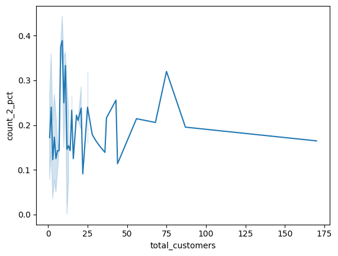

```python
# Visualizing frequency of 2x returning customers by order volume
sns.lineplot(data=fun_pivot, x ='total_customers', y ='count_2_pct')
```

Data amongst 2x repeat customers is very noisy at low volumes, peaking with more stability around 40-80 customers, and then declining beyond 100.

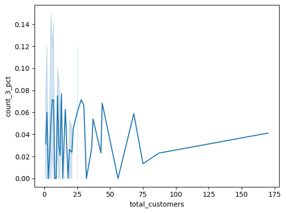

```python
# Visualizing frequency of 3x returning customers by order volume
sns.lineplot(data=fun_pivot, x ='total_customers', y ='count_3_pct')
```

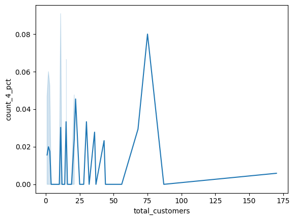

```python
# Visualizing frequency of 4x returning customers by order volume
sns.lineplot(data=fun_pivot, x ='total_customers', y ='count_4_pct')
```

Similar to 3x repeat customers, 4x repeat customer probability shows noise at low volumes, has a single outlier spike around the 75 customers and approaches zero at high volumes.

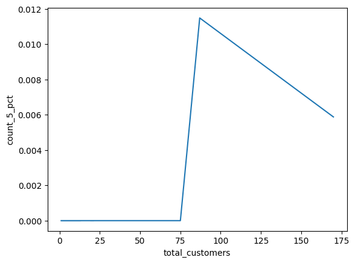

```python
# Visualizing frequency of 5x returning customers by order volume
sns.lineplot(data=fun_pivot, x ='total_customers', y ='count_5_pct')
```

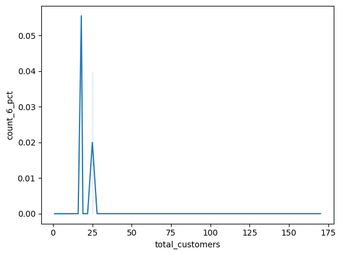

```python
# Visualizing frequency of 6x returning customers by order volume
sns.lineplot(data=fun_pivot, x ='total_customers', y ='count_6_pct')
```

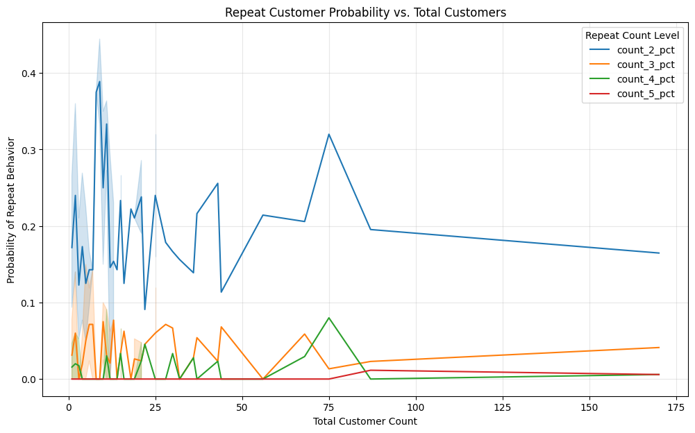

```python
# Creating table that showcases all (up to 5x) frequencies of customer return rates
plt.figure(figsize=(12, 7))

# Treating percentage columns as hue
repeat_cols = [
    'count_2_pct',
    'count_3_pct',
    'count_4_pct',
    'count_5_pct',
]
# Generating table
for col in repeat_cols:
    sns.lineplot(
        data=fun_pivot.sort_values('total_customers'),
        x='total_customers',
        y=col,
        label=col
    )

plt.title("Repeat Customer Probability vs. Total Customers")
plt.xlabel("Total Customer Count")
plt.ylabel("Probability of Repeat Behavior")
plt.legend(title="Repeat Count Level")
plt.grid(alpha=0.3)
plt.show()
```

### Conclusion and Recommendations

### Conclusions:

- A significantly higher volume of orders are placed on weekends and delivery drivers move faster to accomodate the higher volumes.
- Cost of orders, total time to receive orders and ratings tend to show less correlation with one another. Though certain cuisines show light variation and there are slight patterns within their average costs and prep times, it isn't the cuisine itself that has the most impact on popularity per se.
- The top restaurants that absorb the majority of the market tend to have slightly tighter windows of cost and waiting time, indicating a more streamlined system in place that has greater potential to consistently match customer expectations.
- Though customer loyalty was shown not to have nearly as high an impact on driving up order volume as the sheer numbers of customer bases, it does tend to show a trend of driving up sales the most for establishments in the mid-ranking level of order volume.
- One large key factor shown was that there seems to be an evident cycle of higher volumes of ratings being produced by higher volume establishments. Though obvious that this would be the case, it is important to note that we showed there was a drastically higher proportion of ratings given per restaurant in the high-demand cuisines vs their lesser counterparts.

### Recommendations:

Given that Food Hub makes a percentage on the dollar for all orders delivered, it is in the company's best interest that all restaurants across the board do more business. Please review the following reccomendations:

### 1. Driving up ratings

More ratings spells out more visibility and thus more order volume. Consumers are largely driven by peer reviews and look for a measure of security in their investments of all kinds (even where they order food).

All restaurants and especially those in need of volume should implement better strategies for acquiring ratings, for example:

- Implementing a points system that rewards leaving non-partisan ratings and builds a credit applied toward future orders.
- Rewarding consumer interaction for hitting milestones of leaving ratings and reviews.
- Working on improving their interface to increase the likelihood of each consumer leaving a rating.

### 2. Bringing more business to weekdays

The vast majority of orders are placed on weekends, and its worth noting that weekdays outnumber weekends by 3 days -- this is a lot of wasted potential. They could improve this by:

- Encouraging business within their database to offer promotional deals on weekdays; happy hour, two-for-one Tuesdays etc. to better drive up sales on these days.
- Offering reduced surcharges on these days, to further encourage consumers to order in .
- Rewarding speedy drivers: there tends to be a lag in delivery speeds on weekdays. People are busier on weeknights; if they know they'll get something faster, they're likelier to buy.

### 3. Campaigning for low-volume establishments

Smaller restaurants need to focus on bringing in higher volume more than anything. In addition to bringing strong emphasis to better ratings acquisitions, Foodhub should consider:

- Offering their platform as a sounding board for advertising and in turn growing business' social media followings through association
- Offering lower surcharges to restaurants that meet social media campaign and ratings quotas.

Certain restaurants show great models for customer satisfaction, like those of Korean cuisine with their consistently short wait times and affordable prices. Places like these with the right campaign strategy have tons of potential.

### 4. Tapping into the customer basis potential

- Encouraging businesses to implement loyalty programs that are accessed and managed through Foodhub's platform.

On the flip-side, large businesses with models based on volume thrive by acquiring large scales of single visit customers through their broad reach. They could focus on even further maximizing business by reducing customer churn. Foodhub's strategies for this might include:

- Also encouraging loyalty programs through their platform
- Increasing 'stickiness' by streamlining user selection ('Order it again') and bundling options ('Add Shakeshack on for dessert with only $1.00 additional delivery fee!')
- Designing volume-based incentives, such as combo meals and discounts (buy 2 get 1 free).

### 5. Encouraging consistency

The biggest players in the dataset show the most consistency in their pricing and timing. This could be improved for the entire basis by measures such as:

- Encouraging businesses to limit their menu availability (reserving time-consuming dishes for dine-in only).
- Improving onboarding for new businesses ('These time windows, price margins, dish types and so forth make for an ideal Foodhub profile..').
- Rewarding and promoting businesses that hit consistency marks best.